Social Perception of Body Morphology in Sports Students  
Pilot study

Master of Science (MSc) — Engineering and Ergonomics of Physical Activity  
Faculty of Sports and Health Sciences (UFR STAPS)  
University of Montpellier

**Author:** Delphine Hund (Master 1 IEAP Digimove)  
**Supervisors:** Ludovic Marin, Mathilde Parisi, Stéphane Raffard, Rachel F. Rodgers  
**Course:** Python, R and Git for Data Analysis  
**Academic Year:** 2025–2026  
**Date of Defense:** Tuesday 17 March 2026

**GitHub Repository:** https://github.com/DelphineHun-student/Hund.Delphine-Project

02.1_processing.Rmd — Statistical Report (Final validation)

**Experiment summary**

This pilot study aims to validate the perceived morphology of dynamic avatars. Participants viewed 4 animated avatars (randomized order) and rated each avatar on 6 adjective-based dimensions: athletic, average, overweight, obese, thin, skinny.

The mapping between ratings and avatars is reconstructed using: - VS03_01 … VS03_04: the avatar identifier presented at each position (slot) - PM01_01 … PM72_01: 72 ratings corresponding to 12 blocks of 6 adjectives (fixed order within each block)

**Hypotheses**

For each avatar, ratings will be higher on the adjective matching its intended morphology than on the non-matching adjectives (congruent > incongruent).

**Final validation**

The present analyses are based on the last version of the pilot study questionnaire and stimulus set, including the following modifications:

- Updated female athletic avatar (more muscle).
- Updated female skinny avatr (thinner).
- Updated male thin avatar (thinner).

## 1 Initiate

### 1.1 Packages

### 1.2 Set directory

```r
PATH <- dirname(getwd())
DAT_PATH = file.path(PATH, "DAT")
CLEAN_PATH = file.path(DAT_PATH, "clean")
RES_PATH = file.path(PATH, "RES")
TABLES_DIR <- file.path(RES_PATH, "tables_revalidation")
```

### 1.3 Read data

```r
file_xlsx <- file.path(CLEAN_PATH, "pre_manip_ratings_new.xlsx")

ratings_long <- read_excel(file_xlsx)
```

## 2 Data preparation

### 2.1 Data integrity check

```r
ratings_long %>%
  count(CASE) %>%
  summarise(min_n = min(n), max_n = max(n))
```

```
## # A tibble: 1 × 2
##   min_n max_n
##   <int> <int>
## 1    24    24
```

### 2.2 Variables types

We explicitly define variable types to ensure correct statistical modeling.

```r
ratings_long <- ratings_long %>%
  mutate(
    CASE = as.factor(CASE), # Participant identifier
    avatar = as.character(avatar), # Avatar label
    adjectif = as.factor(adjectif), # Within-subject factor
    note = as.numeric(note), # Rating value
    DE03x01 = as.numeric(DE03x01), # Age
    DE08 = as.numeric(DE08) # Gender code (1 = Female ; 2 = Male ; 3 = Other)
  )
```

### 2.3 Exclusion

Participants reporting significant eating disorder or body dysmorphic symptoms (DE10 = 2 or 3) were excluded from further analyses.

```r
excluded_participants <- ratings_long %>%
  filter(DE10 %in% c(2, 3)) %>%
  distinct(CASE)

n_total <- ratings_long %>%
  distinct(CASE) %>%
  nrow()

n_excluded <- nrow(excluded_participants)
n_included <- n_total - n_excluded

ratings_clean <- ratings_long %>%
  filter(!(CASE %in% excluded_participants$CASE))

exclusion_summary <- tibble(
  Category = c("Total participants",
               "Excluded (DE10 = 2 or 3)",
               "Included in analyses"),
  N = c(n_total, n_excluded, n_included)
)
exclusion_summary
```

```
## # A tibble: 3 × 2
##   Category                     N
##   <chr>                    <int>
## 1 Total participants          26
## 2 Excluded (DE10 = 2 or 3)     6
## 3 Included in analyses        20
```

## 3 Descriptive statistics

### 3.1 Demographics: sample description

Age (mean ± SD) and gender distribution for the final included sample.

```r
demographics <- ratings_clean %>%
  distinct(CASE, DE03x01, DE08)

demographics_summary <- demographics %>%
  summarise(
    N_total = n(),
    Mean_age = round(mean(DE03x01, na.rm = TRUE), 2),
    SD_age = round(sd(DE03x01, na.rm = TRUE), 3),
    N_female = sum(DE08 == 1, na.rm = TRUE),
    N_male   = sum(DE08 == 2, na.rm = TRUE),
    N_other  = sum(DE08 == 3,na.rm = TRUE)
  )

demographics_summary
```

```
## # A tibble: 1 × 6
##   N_total Mean_age SD_age N_female N_male N_other
##     <int>    <dbl>  <dbl>    <int>  <int>   <int>
## 1      20     36.7   16.9        9     10       0
```

### 3.2 Ratings by avatar × adjective

We report mean and standard deviation of ratings for each avatar across the six adjective dimensions.

```r
desc_avatar_adj <- ratings_clean %>%
  group_by(avatar, adjectif) %>%
  summarise(
    Mean = mean(note),
    SD = round(sd(note, na.rm = TRUE), 2),
    N = n(),
    .groups = "drop"
  ) %>%
  arrange(avatar, adjectif)

desc_avatar_adj
```

```
## # A tibble: 48 × 5
##    avatar           adjectif    Mean    SD     N
##    <chr>            <fct>      <dbl> <dbl> <int>
##  1 F_ATH_W_D.mp4    athletic   81.6  19.6     19
##  2 F_ATH_W_D.mp4    average    48.4  24.1     19
##  3 F_ATH_W_D.mp4    obese      16    23.3     19
##  4 F_ATH_W_D.mp4    overweight 18.8  19.8     19
##  5 F_ATH_W_D.mp4    skinny      7.79 14.7     19
##  6 F_ATH_W_D.mp4    thin       29.8  20.4     19
##  7 F_SKINNY_W_D.mp4 athletic   31    27.8     19
##  8 F_SKINNY_W_D.mp4 average    33.9  26.2     19
##  9 F_SKINNY_W_D.mp4 obese       1.42  0.77    19
## 10 F_SKINNY_W_D.mp4 overweight  5.26 16.0     19
## # ℹ 38 more rows
```

### 3.3 Export

```r
wb_desc <- createWorkbook()

addWorksheet(wb_desc, "exclusion_summary")
writeData(wb_desc, "exclusion_summary", exclusion_summary)

addWorksheet(wb_desc, "demographics_summary")
writeData(wb_desc, "demographics_summary", demographics_summary)

addWorksheet(wb_desc, "ratings_avatar_adj")
writeData(wb_desc, "ratings_avatar_adj", desc_avatar_adj)

saveWorkbook(
  wb_desc,
  file = file.path(TABLES_DIR, "descriptive_statistics.xlsx"),
  overwrite = TRUE
)
save_table_png <- function(df, filename){
  gt_table <- gt(df)
  gtsave(
    gt_table,
    filename = filename
  )
}

save_table_png(
  exclusion_summary,
  file.path(TABLES_DIR, "exclusion_summary.png")
)
```

```
## file:////var/folders/s7/l40675nx1_b8x31mxcqljfqr0000gn/T//RtmprwfNoe/file5eff6d5abe23.html screenshot completed
```

```r
save_table_png(
  demographics_summary,
  file.path(TABLES_DIR, "demographics_summary.png")
)
```

```
## file:////var/folders/s7/l40675nx1_b8x31mxcqljfqr0000gn/T//RtmprwfNoe/file5eff15920e1a.html screenshot completed
```

```r
save_table_png(
  desc_avatar_adj,
  file.path(TABLES_DIR, "ratings_avatar_adjective.png")
)
```

```
## file:////var/folders/s7/l40675nx1_b8x31mxcqljfqr0000gn/T//RtmprwfNoe/file5eff27dbd806.html screenshot completed
```

```r
ratings_clean %>%
  group_by(avatar) %>%
  summarise(
    n_participants = n_distinct(CASE),
    n_adjectifs = n_distinct(adjectif),
    n_rows = n(),
    .groups = "drop"
  )
```

```
## # A tibble: 8 × 4
##   avatar           n_participants n_adjectifs n_rows
##   <chr>                     <int>       <int>  <int>
## 1 F_ATH_W_D.mp4                19           6    114
## 2 F_SKINNY_W_D.mp4             19           6    114
## 3 F_THIN_W_D.mp4               19           6    114
## 4 M_THIN_W_D.mp4               19           6    114
## 5 Save: Avatar 1                1           6      6
## 6 Save: Avatar 2                1           6      6
## 7 Save: Avatar 3                1           6      6
## 8 Save: Avatar 4                1           6      6
```

## 4 Manip-check

### 4.1 Congruence code

We extract each avatar’s intended morphology from its filename (e.g., `_ATH_`, `_AVG_`) and define whether each rating is *congruent* (adjective matches intended morphology) or *incongruent*.

```r
avatars_valides <- c(
  "F_ATH_W_D.mp4",
  "F_SKINNY_W_D.mp4",
  "F_THIN_W_D.mp4",
  "M_THIN_W_D.mp4"
)

ratings_clean <- ratings_clean %>%
  filter(avatar %in% avatars_valides)
morpho_levels <- c("athletic","average","overweight","obese","thin","skinny")

ratings_clean <- ratings_clean %>%
  mutate(
    morpho_target = case_when(
      str_detect(avatar, "_ATH_")    ~ "athletic",
      str_detect(avatar, "_AVG_")    ~ "average",
      str_detect(avatar, "_OBESE_")  ~ "obese",
      str_detect(avatar, "_THIN_")   ~ "thin",
      str_detect(avatar, "_SKINNY_") ~ "skinny",
      TRUE ~ NA_character_
    ),
    morpho_target = factor(morpho_target, levels = morpho_levels),
    congruence = ifelse(adjectif == morpho_target, "congruent", "incongruent"),
    congruence = factor(congruence, levels = c("incongruent", "congruent"))
  )
# Check
table_morpho <- table(ratings_clean$morpho_target, useNA = "ifany")
table_congruence <- table(ratings_clean$congruence, useNA = "ifany")

table_morpho
```

```
##
##   athletic    average overweight      obese       thin     skinny
##        114          0          0          0        228        114
```

```r
table_congruence
```

```
##
## incongruent   congruent
##         380          76
```

### 4.2 RM-ANOVA

```r
adjectifs <- levels(ratings_clean$adjectif)

# RM-ANOVA per avatar (global effect of adjective)
run_rm_anova <- function(data_av){ # data_av = data of ONE avatar
  data_av <- data_av %>% mutate(CASE = as.factor(CASE))

  aov_mod <- aov(note ~ adjectif + Error(CASE/adjectif), data = data_av)
  aov_sum <- summary(aov_mod)

  # Extract the adjective effect (within-subject)
  aov_table <- tryCatch({
    tab <- as.data.frame(aov_sum[["Error: CASE:adjectif"]][[1]]) %>%
      tibble::rownames_to_column("term") %>%
      filter(term == "adjectif") %>%
      transmute(
        df1 = Df,
        df2 = aov_sum[["Error: CASE:adjectif"]][[1]]["Residuals","Df"],
        F = `F value`,
        p_value = `Pr(>F)`
      )
    tab
  }, error = function(e){
    tibble(df1 = NA, df2 = NA, F = NA, p_value = NA)
  })

  aov_table
}
```

### 4.3 Planned contrasts

We then conduct planned contrasts comparing the target adjective (i.e., the adjective corresponding to the avatar’s intended morphology) against each of the five non-target adjectives.

All post-hoc comparisons are corrected for multiple testing using the Holm method.

```r
run_planned_contrasts <- function(data_av, adjectives = adjectifs) {
  target <- unique(data_av$morpho_target)
  stopifnot(length(target) == 1)

  lm_mod <- lm(note ~ CASE + adjectif, data = data_av)
  emm <- emmeans(lm_mod, ~ adjectif)

  others <- adjectifs[adjectifs != target]

  contr_list <- setNames(
    lapply(others, function(adj){
      v <- rep(0, length(adjectifs)); names(v) <- adjectifs
      v[target] <- 1
      v[adj] <- -1
      v
    }),
    paste0(target, " - ", others)
  )

  ph <- contrast(emm, contr_list) %>%
    as.data.frame() %>%
    transmute(
      compared_to = str_replace(contrast, paste0("^", target, " - "), ""),
      estimate = estimate,
      SE = SE,
      df = df,
      t = t.ratio,
      p_value = p.value
    ) %>%
    mutate(
      p_adj = p.adjust(p_value, method = "holm"),
      significant = p_adj < .05
    )
  ph
}

out <- ratings_clean %>%
  group_by(avatar) %>%
  group_modify(~{
    data_av <- .x
    target <- unique(data_av$morpho_target)

    tibble(
      morpho_target = target,
      anova = list(run_rm_anova(data_av)),
      posthoc = list(run_planned_contrasts(data_av))
    )
  }) %>%
  ungroup()

anova_by_avatar <- out %>%
  tidyr::unnest(anova) %>%
  select(avatar, morpho_target, df1, df2, F, p_value)

posthoc_by_avatar <- out %>%
  tidyr::unnest(posthoc) %>%
  select(avatar, morpho_target, compared_to, estimate, t, p_value, p_adj, significant)

anova_by_avatar
```

```
## # A tibble: 0 × 6
## # ℹ 6 variables: avatar <chr>, morpho_target <fct>, df1 <dbl>, df2 <dbl>,
## #   F <dbl>, p_value <dbl>
```

```r
posthoc_by_avatar
```

[output not shown]

### 4.4 Validation summary

An avatar is considered validated if all planned contrasts (target adjective vs each non-target adjective) are statistically significant after Holm correction.

```r
avatar_validation <- posthoc_by_avatar %>%
  group_by(avatar, morpho_target) %>%
  summarise(
    n_contrasts = n(),
    n_significant = sum(significant),
    all_contrasts_significant = all(significant),
    .groups = "drop"
  ) %>%
  arrange(desc(all_contrasts_significant), avatar)

avatar_validation
```

```
## # A tibble: 4 × 5
##   avatar          morpho_target n_contrasts n_significant all_contrasts_signif…¹
##   <chr>           <fct>               <int>         <int> <lgl>
## 1 F_ATH_W_D.mp4   athletic                5             5 TRUE
## 2 F_SKINNY_W_D.m… skinny                  5             5 TRUE
## 3 F_THIN_W_D.mp4  thin                    5             5 TRUE
## 4 M_THIN_W_D.mp4  thin                    5             3 FALSE
## # ℹ abbreviated name: ¹all_contrasts_significant
```

```r
# Export
save_table_png(
  avatar_validation,
  file.path(TABLES_DIR, "avatar_validation.png")
)
```

```
## file:////var/folders/s7/l40675nx1_b8x31mxcqljfqr0000gn/T//RtmprwfNoe/file5eff7899058f.html screenshot completed
```

## 5 Plots and export

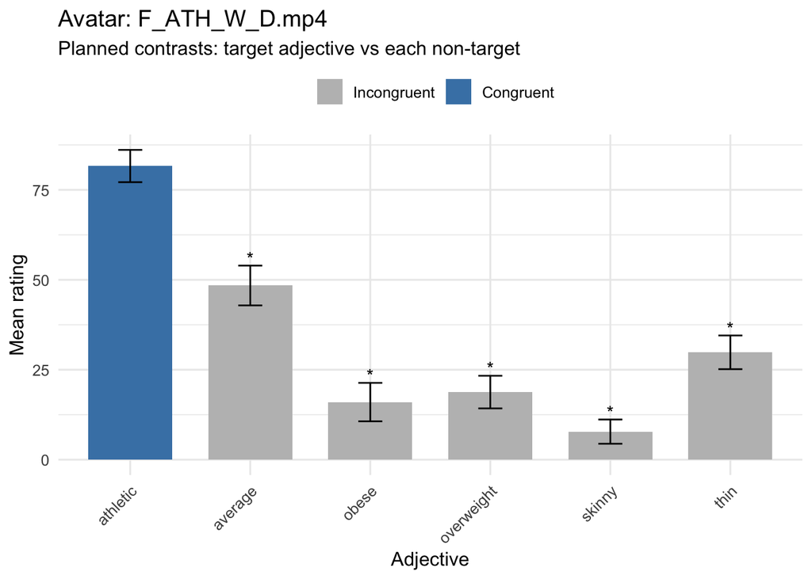

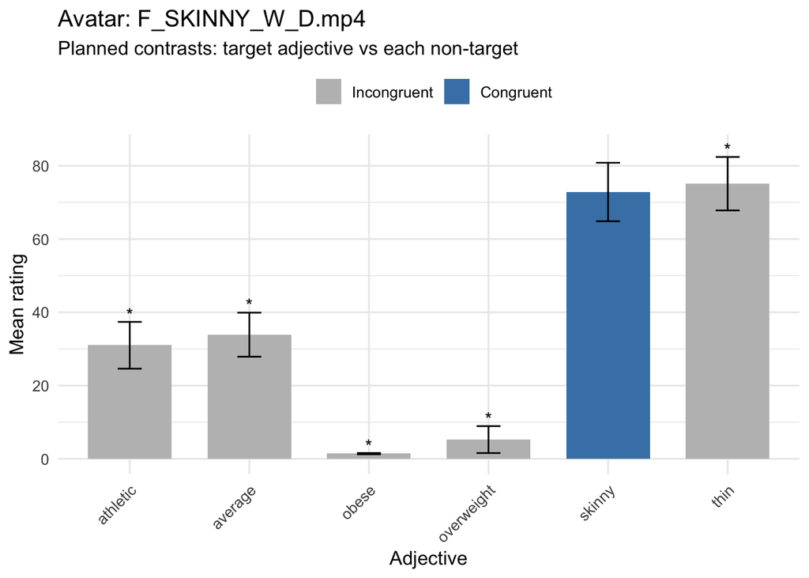

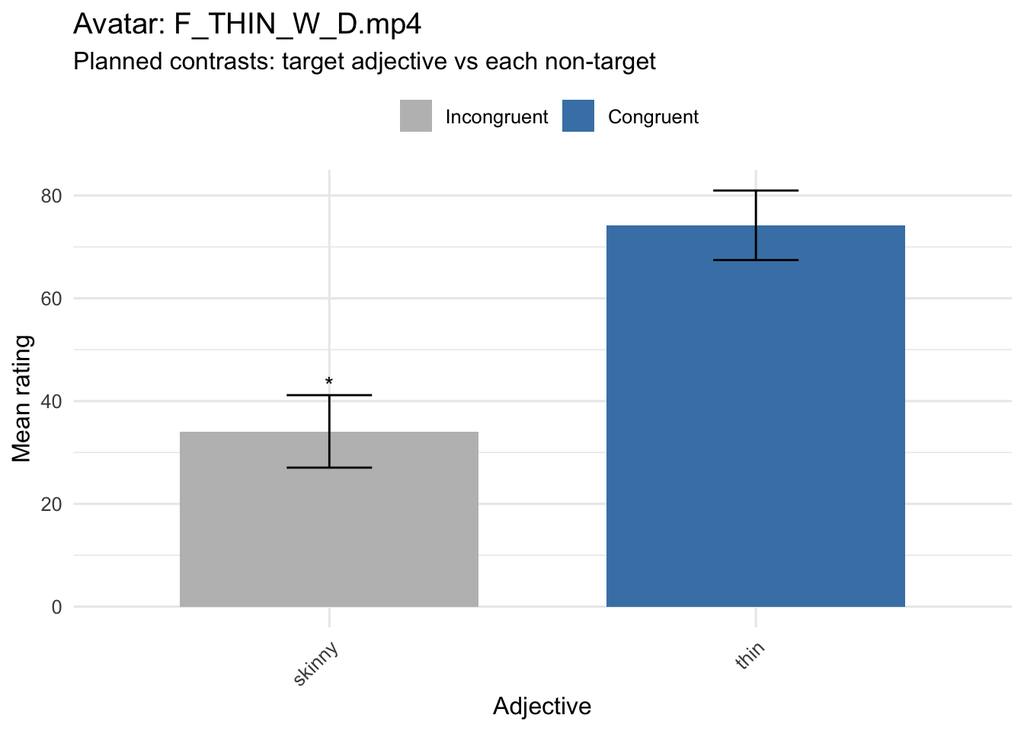

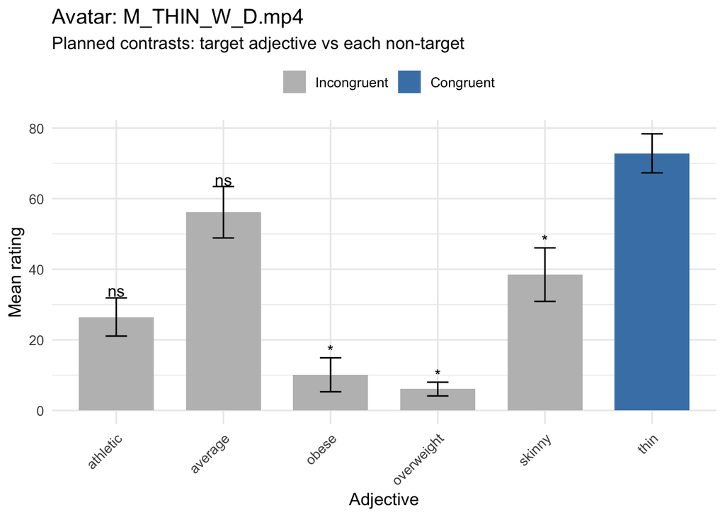

```r
# Mean + SEM per avatar × adjective
plot_data <- ratings_clean %>%
  group_by(avatar, adjectif, morpho_target) %>%
  summarise(
    mean_note = mean(note, na.rm = TRUE),
    sem = sd(note, na.rm = TRUE) / sqrt(sum(!is.na(note))),
    .groups = "drop"
  )

# Significance labels from post-hoc results
sig_labels <- posthoc_by_avatar %>%
  mutate(label = ifelse(significant, "*", "ns")) %>%
  left_join(
    plot_data,
    by = c("avatar", "morpho_target", "compared_to" = "adjectif")
  ) %>%
  mutate(y_pos = mean_note + sem + 2)

# Plot function (one avatar)
plot_one_avatar <- function(av_id){

  pd_av <- plot_data %>% filter(avatar == av_id)
  sg_av <- sig_labels %>% filter(avatar == av_id)

  # Cas particulier : pour F_THIN_W_D.mp4, afficher seulement THIN et SKINNY
  if (av_id == "F_THIN_W_D.mp4") {
    pd_av <- pd_av %>%
      filter(adjectif %in% c("thin", "skinny"))

    sg_av <- sg_av %>%
      filter(compared_to %in% c("skinny"))
  }

  ggplot(pd_av, aes(x = adjectif, y = mean_note)) +
    geom_col(aes(fill = adjectif == morpho_target), width = 0.7) +
    geom_errorbar(aes(ymin = mean_note - sem, ymax = mean_note + sem), width = 0.2) +
    geom_text(
      data = sg_av,
      aes(x = compared_to, y = y_pos, label = label),
      size = 4
    ) +
    scale_fill_manual(
      values = c("grey", "steelblue"),
      labels = c("Incongruent", "Congruent"),
      name = ""
    ) +
    labs(
      title = paste("Avatar:", av_id),
      subtitle = "Planned contrasts: target adjective vs each non-target",
      x = "Adjective",
      y = "Mean rating"
    ) +
    theme_minimal(base_size = 12) +
    theme(
      axis.text.x = element_text(angle = 45, hjust = 1),
      legend.position = "top"
    )
}

# Export one PNG file per avatar
avatar_list <- sort(unique(plot_data$avatar))
walk(avatar_list, ~ print(plot_one_avatar(.x)))
```

```r
PLOTS_DIR <- file.path(RES_PATH, "plots_avatar_new")
if (!dir.exists(PLOTS_DIR)) dir.create(PLOTS_DIR, recursive = TRUE)

walk(avatar_list, function(av){
  p <- plot_one_avatar(av)
  safe_name <- str_replace_all(av, "[^A-Za-z0-9_-]", "_")
  out_png <- file.path(PLOTS_DIR, paste0("plot_", safe_name, ".png"))

  ggsave(
    filename = out_png,
    plot = p,
    width = 10, height = 6, units = "in",
    dpi = 300, bg = "white"
  )
})
```